# Linear Regression on MTCARS Dataset

The dataset, *mtcars* is an in-built data set about cars which contains 32 observations and 11 variables.

https://stat.ethz.ch/R-manual/R-devel/library/datasets/html/mtcars.html

The data was extracted from the 1974 Motor Trend US magazine, and comprises fuel consumption and 10 aspects of automobile design and performance for 32 automobiles (1973–74 models).

| Sl No | Variable | Description |
| --- | --- | --- |
| 1 | mpg | Miles/(US) gallon |
| 2 | cyl | Number of cylinders |
| 3 | disp | Displacement (cu.in.) |
| 4 | hp | Gross horsepower |
| 5 | drat | Rear axle ratio |
| 6 | wt | Weight (1000 lbs) |
| 7 | qsec | 1/4 mile time |
| 8 | vs | Engine (0 = V-shaped, 1 = straight) |
| 9 | am | Transmission (0 = automatic, 1 = manual) |
| 10 | gear | Number of forward gears |
| 11 | carb | Number of carburetors |

#### a. Construct a scatter plot to show the relationship between the variables cars.mpg and cars.wt

#### b. Measure the relative strength of a linear relationship between the cars.mpg and cars.wt by calculating the sample correlation coefficient

#### c. Give your inference on the relationship between these variables

#### d. Give the simple linear regression equation between cars.mpg and cars.wt

```python
import pandas as pd
import numpy as np
import matplotlib.pyplot as plt
import seaborn as sns
import statsmodels.api as sm
```

```python
# Importing MTCARS Dataset from statsmodel.api
mtcars = sm.datasets.get_rdataset("mtcars").data
```

```python
type(mtcars)
```

```
pandas.core.frame.DataFrame
```

```python
# Checking the First 05 Rows of the Dataset
mtcars.head()
```

|  | mpg | cyl | disp | hp | drat | wt | qsec | vs | am | gear | carb |
| --- | --- | --- | --- | --- | --- | --- | --- | --- | --- | --- | --- |
| Mazda RX4 | 21.0 | 6 | 160.0 | 110 | 3.90 | 2.620 | 16.46 | 0 | 1 | 4 | 4 |
| Mazda RX4 Wag | 21.0 | 6 | 160.0 | 110 | 3.90 | 2.875 | 17.02 | 0 | 1 | 4 | 4 |
| Datsun 710 | 22.8 | 4 | 108.0 | 93 | 3.85 | 2.320 | 18.61 | 1 | 1 | 4 | 1 |
| Hornet 4 Drive | 21.4 | 6 | 258.0 | 110 | 3.08 | 3.215 | 19.44 | 1 | 0 | 3 | 1 |
| Hornet Sportabout | 18.7 | 8 | 360.0 | 175 | 3.15 | 3.440 | 17.02 | 0 | 0 | 3 | 2 |

```python
# print the mtcars info
mtcars.info()
```

```
<class 'pandas.core.frame.DataFrame'>
Index: 32 entries, Mazda RX4 to Volvo 142E
Data columns (total 11 columns):
mpg     32 non-null float64
cyl     32 non-null int64
disp    32 non-null float64
hp      32 non-null int64
drat    32 non-null float64
wt      32 non-null float64
qsec    32 non-null float64
vs      32 non-null int64
am      32 non-null int64
gear    32 non-null int64
carb    32 non-null int64
dtypes: float64(5), int64(6)
memory usage: 3.0+ KB
```

```python
mtcars.describe()
```

|  | mpg | cyl | disp | hp | drat | wt | qsec | vs | am | gear | carb |
| --- | --- | --- | --- | --- | --- | --- | --- | --- | --- | --- | --- |
| count | 32.000000 | 32.000000 | 32.000000 | 32.000000 | 32.000000 | 32.000000 | 32.000000 | 32.000000 | 32.000000 | 32.000000 | 32.0000 |
| mean | 20.090625 | 6.187500 | 230.721875 | 146.687500 | 3.596563 | 3.217250 | 17.848750 | 0.437500 | 0.406250 | 3.687500 | 2.8125 |
| std | 6.026948 | 1.785922 | 123.938694 | 68.562868 | 0.534679 | 0.978457 | 1.786943 | 0.504016 | 0.498991 | 0.737804 | 1.6152 |
| min | 10.400000 | 4.000000 | 71.100000 | 52.000000 | 2.760000 | 1.513000 | 14.500000 | 0.000000 | 0.000000 | 3.000000 | 1.0000 |
| 25% | 15.425000 | 4.000000 | 120.825000 | 96.500000 | 3.080000 | 2.581250 | 16.892500 | 0.000000 | 0.000000 | 3.000000 | 2.0000 |
| 50% | 19.200000 | 6.000000 | 196.300000 | 123.000000 | 3.695000 | 3.325000 | 17.710000 | 0.000000 | 0.000000 | 4.000000 | 2.0000 |
| 75% | 22.800000 | 8.000000 | 326.000000 | 180.000000 | 3.920000 | 3.610000 | 18.900000 | 1.000000 | 1.000000 | 4.000000 | 4.0000 |
| max | 33.900000 | 8.000000 | 472.000000 | 335.000000 | 4.930000 | 5.424000 | 22.900000 | 1.000000 | 1.000000 | 5.000000 | 8.0000 |

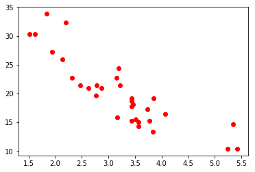

```python
# Construct a scatter plot to show the relationship between the variables cars.mpg and cars.wt
plt.scatter(mtcars.wt, mtcars.mpg, color="r")
```

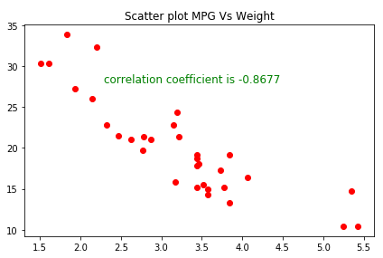

```python
# Printing the Correlation Coefficient
corr = np.corrcoef(mtcars.mpg, mtcars.wt)[0,1]
plt.scatter(mtcars.wt, mtcars.mpg, color="r")
text_cc = '\n\n\n\n\ncorrelation coefficient is %1.4f'%corr
plt.title('Scatter plot MPG Vs Weight')
plt.suptitle(text_cc, color="green")
plt.tight_layout()
```

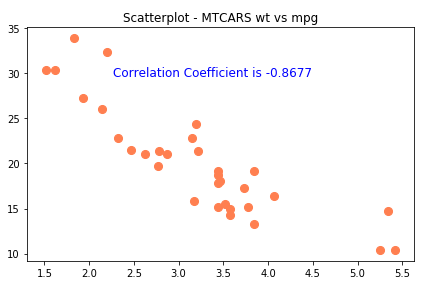

```python
# Printing the Correlation Coefficient
corr = np.corrcoef(mtcars.mpg,mtcars.wt)[0,1]
plt.scatter(mtcars["wt"], mtcars["mpg"], color="coral",s = 65)
plt.title("Scatterplot - MTCARS wt vs mpg")
corrtext = "\n\n\n\nCorrelation Coefficient is %1.4f" %corr
plt.suptitle(corrtext, color="blue")
plt.tight_layout()
```

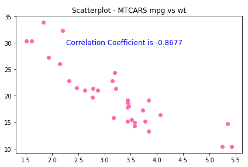

```python
# Creating the Scatterplot and Correlation Coefficient
corr = np.corrcoef(mtcars.mpg, mtcars.wt)[0,1]
plt.scatter(mtcars.wt, mtcars.mpg, color="hotpink")
cortext = "\n\n\n\nCorrelation Coefficient is %1.4f"%corr
plt.title("Scatterplot - MTCARS mpg vs wt")
plt.suptitle(cortext,color="blue")
plt.tight_layout()
```

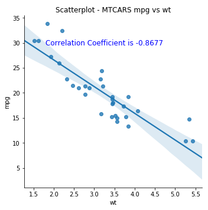

```python
# Creating the Scatterplot and Correlation Coefficient
ax = sns.lmplot(x="wt", y = "mpg", data=mtcars)
corr = np.corrcoef(mtcars.mpg, mtcars.wt)[0,1]
cortext = "\n\n\n\nCorrelation Coefficient is %1.4f"%corr
plt.title("Scatterplot - MTCARS mpg vs wt")
plt.suptitle(cortext,color="blue")
plt.tight_layout()
```

# Finding the Slope and Intercept

```python
ybar = mtcars.mpg.mean()
xbar = mtcars.wt.mean()
```

```python
print(xbar, ybar)
```

```
3.2172499999999995 20.090624999999996
```

```python
yi_ybar = mtcars.mpg-ybar
```

```python
xi_xbar = mtcars.wt-xbar
```

```python
product = (xi_xbar)*(yi_ybar)
```

```python
# powering the xi_xbar
xi_xbarsq = xi_xbar**2
```

```python
sum(product)
```

```
-158.617225
```

```python
sum(xi_xbarsq)
```

```
29.678748
```

```python
slope_m = sum(product)/sum(xi_xbarsq)
```

```python
slope_m
```

```
-5.344471572722677
```

```python
# Lets Find the Linear regression of the same
from scipy import stats
stats.linregress(mtcars.wt, mtcars.mpg)
```

```
LinregressResult(slope=-5.344471572722678, intercept=37.28512616734204, rvalue=-0.8676593765172279, pvalue=1.2939587013504974e-10, stderr=0.559101045099323)
```

```python
# Intercept = ybar - m*xbar
c = ybar - slope_m*xbar
print(c)
```

```
37.28512616734203
```

```python
from sklearn.linear_model import LinearRegression
```

```python
lm = LinearRegression()
```

```python
x = np.array(mtcars.wt).reshape(-1,1)
y = mtcars.mpg
```

```python
lm.fit(x,y)
```

```
LinearRegression(copy_X=True, fit_intercept=True, n_jobs=1, normalize=False)
```

```python
ypred = lm.predict(x)
```

```python
# Sum of Squared Error
sum((y-ypred)**2)
```

```
278.32193754334327
```

```python
mtcars.to_csv("mtcars.csv")
```

```python
import os
os.getcwd()
```

```
'/Users/mukul.singh'
```

```python
from sklearn.metrics import r2_score
```

```python
r2_score(y,ypred)
```

```
0.7528327936582646
```

```python
# Multiple Linear Regression
x = mtcars.drop("mpg", axis = 1)
y = mtcars.mpg
```

```python
from sklearn.model_selection import train_test_split
```

```python
xtrain,xtest,ytrain,ytest = train_test_split(x, y, test_size = 0.30, random_state = 1)
```

```python
lm.fit(xtrain,ytrain)
```

```
LinearRegression(copy_X=True, fit_intercept=True, n_jobs=1, normalize=False)
```

```python
pred= lm.predict(xtest)
```

```python
lm.intercept_
```

```
12.521343823205275
```

```python
lm.coef_
```

```
array([ 0.05642263,  0.00913237, -0.0191569 ,  1.26952627, -2.29502804,
        0.22435961, -0.85832351, -0.4642907 ,  2.57751704, -0.87829683])
```

```python
r2_score(ytest, pred)
```

```
0.6986516223548618
```

```python
print(lm.coef_)
```

```
[ 0.05642263  0.00913237 -0.0191569   1.26952627 -2.29502804  0.22435961
 -0.85832351 -0.4642907   2.57751704 -0.87829683]
```

```python
print(lm.intercept_)
```

```
12.521343823205275
```

```python
# Print SSE
sse = sum((ytest-pred)**2)
```

```python
# Find SST and R Squared
# SST is sum of (y - ybar)^2
sst = sum((ytest-mtcars.mpg.mean())**2)
rsq = 1-(sse/sst)
```

```python
print(rsq)
```

```
0.7112071329301184
```

```python
r2_score(ytest, pred)
```

```
0.6986516223548618
```

```python
model = lm.fit(x, y)
```

```python
ypred = lm.predict(x)
```

```python
lm.coef_
```

```
array([-0.11144048,  0.01333524, -0.02148212,  0.78711097, -3.71530393,
        0.82104075,  0.31776281,  2.52022689,  0.65541302, -0.19941925])
```

```python
# SSE and R2
sse = sum((y-ypred)**2)
sst = sum((y-y.mean())**2)
r2 = 1-(sse/sst)
```

```python
r2
```

```
0.8690157644777647
```

```python
r2_score(y, ypred)
```

```
0.8690157644777647
```

```python
# Step1 - Import Data from Library
# Define X and Y
# Split it if required
# apply linear regression.fit and .predict
# lm.coef_ and lm.intercept_
# Find r2 by sklearn.metrics import r2_score
# r2_score(y, ypred)

# Another way to find r2 score is to calculate by formula r2 = 1-(SSE/SST)
# sse = sum((y-ypred)**2) and sst = sum((y-y.mean())**2)
```

```python
lm.score(X=x,y=y)
```

```
0.8690157644777647
```

```python
x=np.array(mtcars["wt"]).reshape(-1,1)
y = mtcars.mpg
```

```python
lm.fit(x,y)
```

```
LinearRegression(copy_X=True, fit_intercept=True, n_jobs=1, normalize=False)
```

```python
pred = lm.predict(x)
```

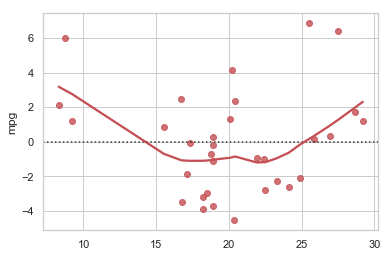

```python
residual = y-pred
sns.residplot(pred,residual, lowess=True, color="r")
```

```python
# Residual Plots
import statsmodels.api as sms
x = mtcars.wt
y = mtcars.mpg
x = sms.add_constant(x)
```

```python
model = sms.OLS(y, x).fit()
```

```python
ols_pred = model.predict(x)
```

```python
residuals = model.resid
fittedvalues = model.fittedvalues
rsq = model.rsquared
print(rsq)
```

```
0.7528327936582646
```

```python
r2_score(y, ols_pred)
```

```
0.7528327936582646
```

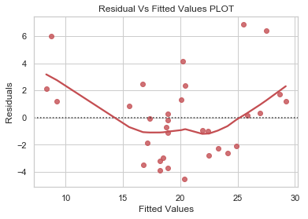

```python
sns.set(style="whitegrid")
ax = sns.residplot(fittedvalues, residuals, lowess=True, color="r")
ax.set(xlabel = "Fitted Values", ylabel = "Residuals",title = "Residual Vs Fitted Values PLOT")
plt.show()
```

```python
# Multiple Linear Regression plot
x = mtcars.drop("mpg", axis = 1)
y = mtcars.mpg
```

```python
lm.fit(x, y)
```

```
LinearRegression(copy_X=True, fit_intercept=True, n_jobs=1, normalize=False)
```

```python
pred = lm.predict(x)
```

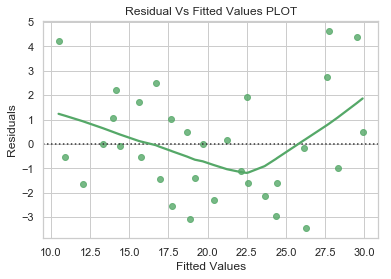

```python
# Create the Residual Plot
ix = sns.residplot(x=pred, y = y-pred, lowess=True,color="g")
ix.set(xlabel = "Fitted Values", ylabel = "Residuals", title = "Residual Vs Fitted Values PLOT")
plt.show()
```

```python
# From statmodels.api
multimodel = sms.OLS(y,x).fit()
multipred = multimodel.predict(x)
```

```python
fitted_values = multimodel.fittedvalues
```

```python
residuals = multimodel.resid
```

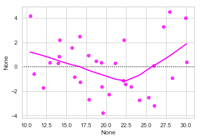

```python
sns.residplot(fitted_values, residuals, lowess=True, color="magenta")
```

```python
r2_score(y, multipred)
```

```
0.8663209139912303
```

#### a. Construct a scatter plot to show the relationship between the variables cars.mpg and cars.wt

#### b. Measure the relative strength of a linear relationship between the cars.mpg and cars.wt by calculating the sample correlation coefficient

#### c. Give your inference on the relationship between these variables

#### d. Give the simple linear regression equation between cars.mpg and cars.wt

```python
import numpy as np
import pandas as pd
import statsmodels.api as sms
import seaborn as sns
import matplotlib.pyplot as plt
from sklearn.linear_model import LinearRegression
```

```python
mtcars = sms.datasets.get_rdataset("mtcars").data
```

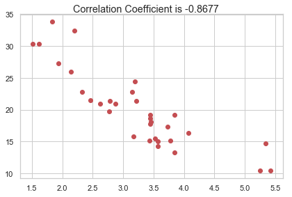

```python
# Plot of Relationship between the WT and MPG
corr = np.corrcoef(mtcars.mpg, mtcars.wt)[0,1]
plt.scatter(mtcars.wt, mtcars.mpg, color="r")
text = "Correlation Coefficient is %1.4f" %corr
plt.suptitle(text)
plt.tight_layout()
plt.show()
```

```python
# Develop SMS Model OLS
y = mtcars.mpg
x = mtcars.wt
x = sms.add_constant(x)
model = sms.OLS(y, x).fit()
pred_model = model.predict(x)
```

```python
# Find the Fitted Values, Residuals and R Squared Values
fittedvals = model.fittedvalues
residual_wt = model.resid
Rsquared = model.rsquared
```

```python
print(Rsquared)
```

```
0.7528327936582646
```

```python
from sklearn.metrics import r2_score
r2_score(y,model.predict(x))
```

```
0.7528327936582646
```

```python
mtcars.head()
```

|  | mpg | cyl | disp | hp | drat | wt | qsec | vs | am | gear | carb |
| --- | --- | --- | --- | --- | --- | --- | --- | --- | --- | --- | --- |
| Mazda RX4 | 21.0 | 6 | 160.0 | 110 | 3.90 | 2.620 | 16.46 | 0 | 1 | 4 | 4 |
| Mazda RX4 Wag | 21.0 | 6 | 160.0 | 110 | 3.90 | 2.875 | 17.02 | 0 | 1 | 4 | 4 |
| Datsun 710 | 22.8 | 4 | 108.0 | 93 | 3.85 | 2.320 | 18.61 | 1 | 1 | 4 | 1 |
| Hornet 4 Drive | 21.4 | 6 | 258.0 | 110 | 3.08 | 3.215 | 19.44 | 1 | 0 | 3 | 1 |
| Hornet Sportabout | 18.7 | 8 | 360.0 | 175 | 3.15 | 3.440 | 17.02 | 0 | 0 | 3 | 2 |

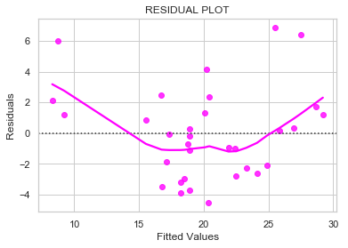

```python
# Residual Plot
ax = sns.residplot(fittedvals, residual_wt, color="magenta", lowess=True)
ax.set(xlabel="Fitted Values",ylabel="Residuals", title = "RESIDUAL PLOT")
plt.show()
```

```python
# Lets Do the Same from Scikit Learn
lm = LinearRegression()
lm.fit(x,y)
model_lm = lm.predict(x)
```

```python
# Find the Fitted Values, Residuals
fitted_values = model_lm
res = y-model_lm
```

```python
r2_score(y, model_lm)
```

```
0.7528327936582646
```

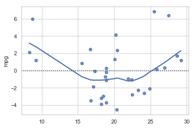

```python
# Residual Plot
sns.residplot(fitted_values, res, lowess=True)
```

```python
# QQ PLOT
from statsmodels.graphics.gofplots import ProbPlot

# fittedvals = model.fittedvalues
# residual_wt = model.resid
# Rsquared = model.rsquared
st_residual = model.get_influence().resid_studentized_internal # residual/st.dev
```

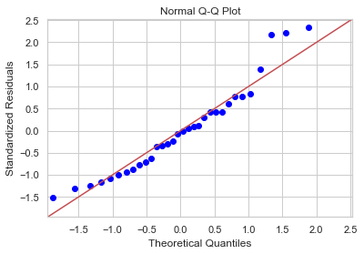

```python
QQ = ProbPlot(st_residual)
plot= QQ.qqplot(line = "45",color = 'blue', lw = 1.5)
plot.axes[0].set_xlabel("Theoretical Quantiles")
plot.axes[0].set_ylabel("Standardized Residuals")
plot.axes[0].set_title("Normal Q-Q Plot")
plt.show()
```

```python
import scipy.stats as stats
import pylab
```

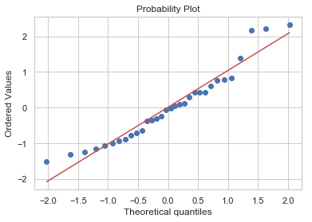

```python
stats.probplot(st_residual, dist="norm", plot=pylab)
plt.show()
```

## Shapiro Wilk Test

### The Shapiro-Wilk test for normality is used to examine a continuous variable.

### The null hypothesis for this test is that the data are normally distributed

If the chosen alpha level is 0.05 and the p-value is less than 0.05, then the null hypothesis that the data are normally distributed is rejected. If the p-value is greater than 0.05, then the null hypothesis is not rejected.

```python
# Test of Normality
from scipy.stats import shapiro
```

```python
test = shapiro(mtcars.drat)
```

```python
if(test[1]<0.05):
    print("Reject the Null Hypothesis")
else:
    print("Fail to Reject the Null Hypothesis")
```

```
Fail to Reject the Null Hypothesis
```

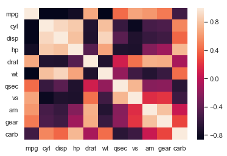

```python
# Creating a Correlation Matrix
corr = mtcars.corr()
sns.heatmap(corr,
            xticklabels=corr.columns.values,
            yticklabels=corr.columns.values)
```

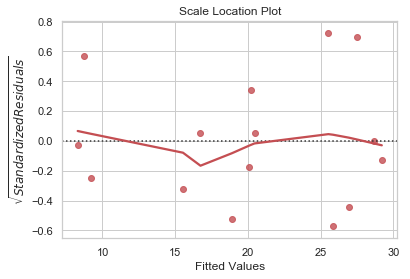

```python
# Scale Location Plot is a plot of Fitted Values vs Sqrt of Standardized Residuals
ax = sns.residplot(fittedvals, np.sqrt(st_residual), lowess=True, color="r")
ax.set(xlabel = "Fitted Values", ylabel = "$\sqrt{Standardized Residuals}$", title = "Scale Location Plot")
plt.show()
```

```python
# Cement Data
cement = pd.read_csv("~/Downloads/concrete.csv")
```

```python
cement.head()
```

|  | cement | slag | ash | water | superplastic | coarseagg | fineagg | age | strength |
| --- | --- | --- | --- | --- | --- | --- | --- | --- | --- |
| 0 | 141.3 | 212.0 | 0.0 | 203.5 | 0.0 | 971.8 | 748.5 | 28 | 29.89 |
| 1 | 168.9 | 42.2 | 124.3 | 158.3 | 10.8 | 1080.8 | 796.2 | 14 | 23.51 |
| 2 | 250.0 | 0.0 | 95.7 | 187.4 | 5.5 | 956.9 | 861.2 | 28 | 29.22 |
| 3 | 266.0 | 114.0 | 0.0 | 228.0 | 0.0 | 932.0 | 670.0 | 28 | 45.85 |
| 4 | 154.8 | 183.4 | 0.0 | 193.3 | 9.1 | 1047.4 | 696.7 | 28 | 18.29 |

```python
cement.info()
```

```
<class 'pandas.core.frame.DataFrame'>
RangeIndex: 1030 entries, 0 to 1029
Data columns (total 9 columns):
cement          1030 non-null float64
slag            1030 non-null float64
ash             1030 non-null float64
water           1030 non-null float64
superplastic    1030 non-null float64
coarseagg       1030 non-null float64
fineagg         1030 non-null float64
age             1030 non-null int64
strength        1030 non-null float64
dtypes: float64(8), int64(1)
memory usage: 72.5 KB
```

```python
cement.columns
```

```
Index(['cement', 'slag', 'ash', 'water', 'superplastic', 'coarseagg',
       'fineagg', 'age', 'strength'],
      dtype='object')
```

```python
x = cement.drop("strength", axis = 1)
y = cement.strength
```

```python
#x = sms.add_constant(x)
model_cement = sms.OLS(y,x).fit()
cement_pred = model_cement.predict(x)
```

```python
# Importing Variance Inflation Factor
from statsmodels.stats.outliers_influence import variance_inflation_factor
vif = pd.DataFrame()
vif["VIF Factor"]= [variance_inflation_factor(x.values, j) for j in range(1, x.shape[1])]
```

```python
cement.columns
```

```
Index(['cement', 'slag', 'ash', 'water', 'superplastic', 'coarseagg',
       'fineagg', 'age', 'strength'],
      dtype='object')
```

```python
ce = ['cement', 'slag', 'ash', 'water', 'superplastic', 'coarseagg',
       'fineagg', 'age']
```

```python
# Boston Data - Check if the model measures such as R-square and adjusted R square have
# improved after transforming the predictor variables. Here our target variable is MEDV.

from sklearn.datasets import load_boston
```

```python
boston = load_boston()
```

```python
bostonn = pd.DataFrame(boston.data)
```

```python
bostonn.columns = boston.feature_names
```

```python
bostonn.head()
bostonn["MEDV"] = boston.target
```

|  | CRIM | ZN | INDUS | CHAS | NOX | RM | AGE | DIS | RAD | TAX | PTRATIO | B | LSTAT | MEDV |
| --- | --- | --- | --- | --- | --- | --- | --- | --- | --- | --- | --- | --- | --- | --- |
| 0 | 0.00632 | 18.0 | 2.31 | 0.0 | 0.538 | 6.575 | 65.2 | 4.0900 | 1.0 | 296.0 | 15.3 | 396.90 | 4.98 | 24.0 |
| 1 | 0.02731 | 0.0 | 7.07 | 0.0 | 0.469 | 6.421 | 78.9 | 4.9671 | 2.0 | 242.0 | 17.8 | 396.90 | 9.14 | 21.6 |
| 2 | 0.02729 | 0.0 | 7.07 | 0.0 | 0.469 | 7.185 | 61.1 | 4.9671 | 2.0 | 242.0 | 17.8 | 392.83 | 4.03 | 34.7 |
| 3 | 0.03237 | 0.0 | 2.18 | 0.0 | 0.458 | 6.998 | 45.8 | 6.0622 | 3.0 | 222.0 | 18.7 | 394.63 | 2.94 | 33.4 |
| 4 | 0.06905 | 0.0 | 2.18 | 0.0 | 0.458 | 7.147 | 54.2 | 6.0622 | 3.0 | 222.0 | 18.7 | 396.90 | 5.33 | 36.2 |

```python
bostonn.shape
```

```
(506, 14)
```

```python
print(boston.DESCR)
```

```
Boston House Prices dataset
===========================

Notes
------
Data Set Characteristics:

    :Number of Instances: 506

    :Number of Attributes: 13 numeric/categorical predictive

    :Median Value (attribute 14) is usually the target

    :Attribute Information (in order):
        - CRIM     per capita crime rate by town
        - ZN       proportion of residential land zoned for lots over 25,000 sq.ft.
        - INDUS    proportion of non-retail business acres per town
        - CHAS     Charles River dummy variable (= 1 if tract bounds river; 0 otherwise)
        - NOX      nitric oxides concentration (parts per 10 million)
        - RM       average number of rooms per dwelling
        - AGE      proportion of owner-occupied units built prior to 1940
        - DIS      weighted distances to five Boston employment centres
        - RAD      index of accessibility to radial highways
        - TAX      full-value property-tax rate per $10,000
        - PTRATIO  pupil-teacher ratio by town
        - B        1000(Bk - 0.63)^2 where Bk is the proportion of blacks by town
        - LSTAT    % lower status of the population
        - MEDV     Median value of owner-occupied homes in $1000's

    :Missing Attribute Values: None

    :Creator: Harrison, D. and Rubinfeld, D.L.

This is a copy of UCI ML housing dataset.
http://archive.ics.uci.edu/ml/datasets/Housing


This dataset was taken from the StatLib library which is maintained at Carnegie Mellon University.

The Boston house-price data of Harrison, D. and Rubinfeld, D.L. 'Hedonic
prices and the demand for clean air', J. Environ. Economics & Management,
vol.5, 81-102, 1978.   Used in Belsley, Kuh & Welsch, 'Regression diagnostics
...', Wiley, 1980.   N.B. Various transformations are used in the table on
pages 244-261 of the latter.

The Boston house-price data has been used in many machine learning papers that address regression
problems.

**References**

   - Belsley, Kuh & Welsch, 'Regression diagnostics: Identifying Influential Data and Sources of Collinearity', Wiley, 1980. 244-261.
   - Quinlan,R. (1993). Combining Instance-Based and Model-Based Learning. In Proceedings on the Tenth International Conference of Machine Learning, 236-243, University of Massachusetts, Amherst. Morgan Kaufmann.
   - many more! (see http://archive.ics.uci.edu/ml/datasets/Housing)
```

```python
x = bostonn.drop("MEDV", axis = 1)
x = sm.add_constant(x)
y = boston.target
```

```python
m = sm.OLS(y, x).fit()
```

```python
p = m.predict(x)
```

```python
stndrdresid = m.get_influence().resid_studentized_internal
```

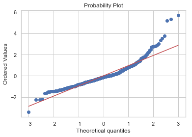

```python
stats.probplot(stndrdresid, dist="norm",plot = pylab)
plt.show()
```

```python
shapiro(stndrdresid)
```

```
(0.8987566232681274, 8.601320139985676e-18)
```

```python
if(shapiro(stndrdresid)[1]<0.05):
    print("Reject the Null")
else:
    print("Accept the Null")
```

```
Reject the Null
```

```python
print(m.rsquared)
print(m.rsquared_adj)
```

```
0.7406077428649427
0.7337538824121872
```

```python
# Improve R Squared
from sklearn.preprocessing import PolynomialFeatures
poly = PolynomialFeatures()
x= poly.fit_transform(x)
```

```python
m = sm.OLS(y, x).fit()
p = m.predict(x)
print(m.rsquared)
print(m.rsquared_adj)
```

```
0.9291464466583611
0.9109924267723193
```

```python
# Import Data - Insurance
insurance = pd.read_csv("~/Downloads/Excel and CSVs/insurance.csv")
```

```python
# Get Dummies
insurance = pd.get_dummies(insurance)
```

```python
insurance.head()
```

|  | age | bmi | children | charges | sex_female | sex_male | smoker_no | smoker_yes | region_northeast | region_northwest | region_southeast | region_southwest |
| --- | --- | --- | --- | --- | --- | --- | --- | --- | --- | --- | --- | --- |
| 0 | 19 | 27.900 | 0 | 16884.92400 | 1 | 0 | 0 | 1 | 0 | 0 | 0 | 1 |
| 1 | 18 | 33.770 | 1 | 1725.55230 | 0 | 1 | 1 | 0 | 0 | 0 | 1 | 0 |
| 2 | 28 | 33.000 | 3 | 4449.46200 | 0 | 1 | 1 | 0 | 0 | 0 | 1 | 0 |
| 3 | 33 | 22.705 | 0 | 21984.47061 | 0 | 1 | 1 | 0 | 0 | 1 | 0 | 0 |
| 4 | 32 | 28.880 | 0 | 3866.85520 | 0 | 1 | 1 | 0 | 0 | 1 | 0 | 0 |

```python
x = insurance.drop("charges", axis = 1)
y = insurance.charges
```

```python
x = sm.add_constant(x)
```

```python
ins_m = sm.OLS(y, x).fit()
```

```python
ins_p = ins_m.predict(x)
```

```python
print(ins_m.rsquared)
print(ins_m.rsquared_adj)
```

```
0.7509130345985207
0.7494136397729286
```

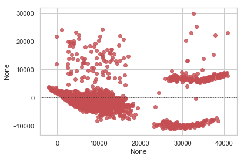

```python
# test of Linearity
sns.residplot(ins_p, ins_m.resid, color = "r")
```

```python
# Test of Normality
st_res = ins_m.get_influence().resid_studentized_internal
shapiro(st_res)
```

```
(0.8990878462791443, 8.723982369294297e-29)
```

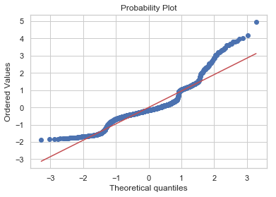

```python
stats.probplot(st_res, dist="norm", plot = pylab)
plt.show()
```

```python
# Lets Apply Polynomial Transformation
from sklearn.preprocessing import PolynomialFeatures
poly = PolynomialFeatures()
```

```python
x = poly.fit_transform(x)
```

```python
ins_m = sm.OLS(y, x).fit()
ins_p = ins_m.predict(x)
print(ins_m.rsquared)
print(ins_m.rsquared_adj)
```

```
0.8477668880499397
0.8435544422158104
```

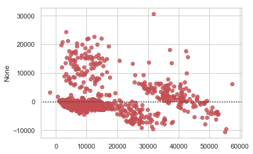

```python
# test of Linearity
sns.residplot(ins_p, ins_m.resid, color = "r")
```

```python
# Test of Normality
st_res = ins_m.get_influence().resid_studentized_internal
shapiro(st_res)
```

```
(0.6726958751678467, 5.605193857299268e-45)
```

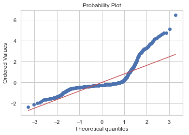

```python
stats.probplot(st_res, dist="norm", plot = pylab)
plt.show()
```

```python
insurance.columns
```

```
Index(['age', 'bmi', 'children', 'charges', 'sex_female', 'sex_male',
       'smoker_no', 'smoker_yes', 'region_northeast', 'region_northwest',
       'region_southeast', 'region_southwest'],
      dtype='object')
```

```python
from sklearn.preprocessing import StandardScaler
```

```python
ss = StandardScaler()
insurance = ss.fit_transform(insurance)
insurance = pd.DataFrame(insurance)
insurance.head()
```

|  | 0 | 1 | 2 | 3 | 4 | 5 | 6 | 7 | 8 | 9 | 10 | 11 |
| --- | --- | --- | --- | --- | --- | --- | --- | --- | --- | --- | --- | --- |
| 0 | -1.438764 | -0.453320 | -0.908614 | 0.298584 | 1.010519 | -1.010519 | -1.970587 | 1.970587 | -0.565267 | -0.566418 | -0.611324 | 1.765481 |
| 1 | -1.509965 | 0.509621 | -0.078767 | -0.953689 | -0.989591 | 0.989591 | 0.507463 | -0.507463 | -0.565267 | -0.566418 | 1.635795 | -0.566418 |
| 2 | -0.797954 | 0.383307 | 1.580926 | -0.728675 | -0.989591 | 0.989591 | 0.507463 | -0.507463 | -0.565267 | -0.566418 | 1.635795 | -0.566418 |
| 3 | -0.441948 | -1.305531 | -0.908614 | 0.719843 | -0.989591 | 0.989591 | 0.507463 | -0.507463 | -0.565267 | 1.765481 | -0.611324 | -0.566418 |
| 4 | -0.513149 | -0.292556 | -0.908614 | -0.776802 | -0.989591 | 0.989591 | 0.507463 | -0.507463 | -0.565267 | 1.765481 | -0.611324 | -0.566418 |

```python
insurance.columns = ['age', 'bmi', 'children', 'charges', 'sex_female', 'sex_male',
       'smoker_no', 'smoker_yes', 'region_northeast', 'region_northwest',
       'region_southeast', 'region_southwest']
```

```python
insurance.head()
```

|  | age | bmi | children | charges | sex_female | sex_male | smoker_no | smoker_yes | region_northeast | region_northwest | region_southeast | region_southwest |
| --- | --- | --- | --- | --- | --- | --- | --- | --- | --- | --- | --- | --- |
| 0 | -1.438764 | -0.453320 | -0.908614 | 0.298584 | 1.010519 | -1.010519 | -1.970587 | 1.970587 | -0.565267 | -0.566418 | -0.611324 | 1.765481 |
| 1 | -1.509965 | 0.509621 | -0.078767 | -0.953689 | -0.989591 | 0.989591 | 0.507463 | -0.507463 | -0.565267 | -0.566418 | 1.635795 | -0.566418 |
| 2 | -0.797954 | 0.383307 | 1.580926 | -0.728675 | -0.989591 | 0.989591 | 0.507463 | -0.507463 | -0.565267 | -0.566418 | 1.635795 | -0.566418 |
| 3 | -0.441948 | -1.305531 | -0.908614 | 0.719843 | -0.989591 | 0.989591 | 0.507463 | -0.507463 | -0.565267 | 1.765481 | -0.611324 | -0.566418 |
| 4 | -0.513149 | -0.292556 | -0.908614 | -0.776802 | -0.989591 | 0.989591 | 0.507463 | -0.507463 | -0.565267 | 1.765481 | -0.611324 | -0.566418 |

```python
x = insurance.drop("charges", axis = 1)
y = insurance.charges
x = sm.add_constant(x)
```

```python
ins_m = sm.OLS(y, x).fit()
ins_p = ins_m.predict(x)
print(ins_m.rsquared)
print(ins_m.rsquared_adj)
```

```
0.7509130345985205
0.7494136397729285
```

[figure not shown]

```python
# test of Linearity
sns.residplot(ins_p, ins_m.resid, color = "r")
```

[figure not shown]

```python
# Test of Normality
st_res = ins_m.get_influence().resid_studentized_internal
stats.probplot(st_res, dist="norm", plot = pylab)
plt.show()
```

```python
# Test of Linearity
sts.linear_rainbow(ins_m) # Check with p value 5%
```

```
(1.129521986322035, 0.05840533768725773)
```

```python
# Test of Normality
shapiro(st_res)
```

[output not shown]

```python
# Residual and Package for Heteroscedasticity
r = ins_m.resid
import statsmodels.stats.api as sts
```

```python
# Test of Heteroscedasticity
sts.het_goldfeldquandt(r, ins_m.model.exog)
```

```
(0.9564376445017754, 0.7162991411316741, 'increasing')
```

```python
# Durbin Watson Test - Test of Autocorrelation
# Null Hypothesis - linear regression residuals are uncorrelated
# Alternate - Autocorrelation exists.
sts.stattools.durbin_watson(r) # No Correlation
```

```
2.0884229986673084
```

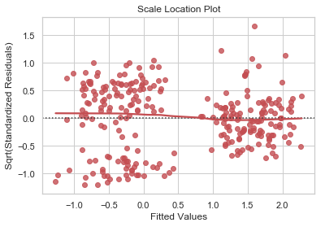

```python
# Scale Location Plot
ax = sns.residplot(ins_m.fittedvalues, np.sqrt(st_res), lowess=True,color="r")
ax.set(xlabel="Fitted Values", ylabel = "Sqrt(Standardized Residuals)", title = "Scale Location Plot")
plt.show()
```

```python
# Heteroscedasiticy xample
cars = sm.datasets.get_rdataset("cars").data
```

```python
# Splitting the Data
x = cars.speed
x = sm.add_constant(cars.speed)
y = cars.dist
```

```python
# Deploying the Model and Prediction
carmodel = sm.OLS(y, x).fit()
pred_car = carmodel.predict(x)
```

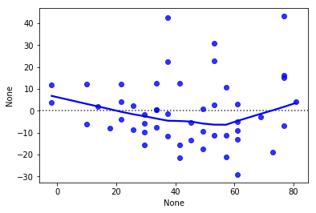

```python
# Residual Plot
sns.residplot(pred_car, carmodel.resid, color="blue", lowess=True)
```

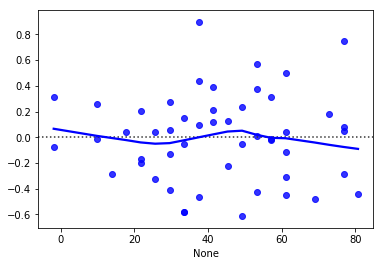

```python
# Scale Location Plot
cars_residuals = carmodel.get_influence().resid_studentized_internal
sns.residplot(pred_car, np.sqrt(np.abs(cars_residuals)), color="blue", lowess=True)
```

```python
# Test of Heteroscedasticity
import statsmodels.stats.api as sts
sts.het_goldfeldquandt(np.sqrt(np.abs(cars_residuals)), carmodel.model.exog)
```

```
(1.021646905470046, 0.47974318608872085, 'increasing')
```

```python
0.47974318608872085<0.05
```

```
False
```

```python
carmodel.summary()
```

OLS Regression Results

| Dep. Variable: | dist | R-squared: | 0.651 |
| --- | --- | --- | --- |
| Model: | OLS | Adj. R-squared: | 0.644 |
| Method: | Least Squares | F-statistic: | 89.57 |
| Date: | Wed, 06 Mar 2019 | Prob (F-statistic): | 1.49e-12 |
| Time: | 08:48:43 | Log-Likelihood: | -206.58 |
| No. Observations: | 50 | AIC: | 417.2 |
| Df Residuals: | 48 | BIC: | 421.0 |
| Df Model: | 1 |  |  |
| Covariance Type: | nonrobust |  |  |

|  | coef | std err | t | P>\|t\| | [0.025 | 0.975] |
| --- | --- | --- | --- | --- | --- | --- |
| const | -17.5791 | 6.758 | -2.601 | 0.012 | -31.168 | -3.990 |
| speed | 3.9324 | 0.416 | 9.464 | 0.000 | 3.097 | 4.768 |

| Omnibus: | 8.975 | Durbin-Watson: | 1.676 |
| --- | --- | --- | --- |
| Prob(Omnibus): | 0.011 | Jarque-Bera (JB): | 8.189 |
| Skew: | 0.885 | Prob(JB): | 0.0167 |
| Kurtosis: | 3.893 | Cond. No. | 50.7 |

Warnings:  
[1] Standard Errors assume that the covariance matrix of the errors is correctly specified.

# Advertising Data

### Objective - To Find if the Advertising Expenditure Really Driving the Sales

#### From ML Stand Point

1. Import the Dataset
2. Try Basic EDA if that is required
3. Split the Data in Train and Test
4. Apply Linear Regression from Scikit Learn
5. Check the Error Metrics

#### Assumptions

1. Import the Dataset
2. Try Basic EDA if that is required
3. Create Linear Regression Model from statsmodels.api
4. Check the Assumptions with Tests and Plots
5. Conclude the Observations

```python
adv = pd.read_csv("~/Downloads/advertising.csv")
```

```python
adv.head()
```

|  | Unnamed: 0 | TV | Radio | Newspaper | Sales |
| --- | --- | --- | --- | --- | --- |
| 0 | 1 | 230.1 | 37.8 | 69.2 | 22.1 |
| 1 | 2 | 44.5 | 39.3 | 45.1 | 10.4 |
| 2 | 3 | 17.2 | 45.9 | 69.3 | 9.3 |
| 3 | 4 | 151.5 | 41.3 | 58.5 | 18.5 |
| 4 | 5 | 180.8 | 10.8 | 58.4 | 12.9 |

```python
adv.columns
```

```
Index(['Unnamed: 0', 'TV', 'Radio', 'Newspaper', 'Sales'], dtype='object')
```

```python
adv = adv.drop('Unnamed: 0', axis = 1)
```

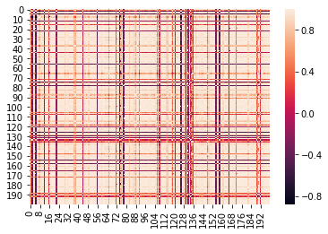

```python
sns.heatmap(np.corrcoef(adv))
```

```python
from sklearn.linear_model import LinearRegression
from sklearn.metrics import mean_absolute_error, mean_squared_error
from sklearn.model_selection import train_test_split
```

```python
lm = LinearRegression()
```

```python
x = adv.drop("Sales", axis= 1)
y = adv.Sales
```

```python
xtrain,xtest,ytrain,ytest = train_test_split(x, y, test_size = 0.30, random_state = 123)
```

```python
lm.fit(xtrain,ytrain)
```

```
LinearRegression(copy_X=True, fit_intercept=True, n_jobs=1, normalize=False)
```

```python
pred_lm = lm.predict(xtest)
```

```python
# MAE & RMSE - train
print(mean_absolute_error(ytrain,lm.predict(xtrain)))
print(np.sqrt(mean_squared_error(ytrain,lm.predict(xtrain))))
```

```
1.3319897007579353
1.7613917369368022
```

```python
# Test Error Values
print(mean_absolute_error(ytest,pred_lm))
print(np.sqrt(mean_squared_error(ytest, pred_lm)))
```

```
1.15604990178548
1.4472433065929022
```

```python
adv.describe()
```

|  | TV | Radio | Newspaper | Sales |
| --- | --- | --- | --- | --- |
| count | 200.000000 | 200.000000 | 200.000000 | 200.000000 |
| mean | 147.042500 | 23.264000 | 30.554000 | 14.022500 |
| std | 85.854236 | 14.846809 | 21.778621 | 5.217457 |
| min | 0.700000 | 0.000000 | 0.300000 | 1.600000 |
| 25% | 74.375000 | 9.975000 | 12.750000 | 10.375000 |
| 50% | 149.750000 | 22.900000 | 25.750000 | 12.900000 |
| 75% | 218.825000 | 36.525000 | 45.100000 | 17.400000 |
| max | 296.400000 | 49.600000 | 114.000000 | 27.000000 |

```python
import statsmodels.api as sms
```

```python
x = adv.drop("Sales", axis= 1)
x = sms.add_constant(x)
y = adv.Sales
```

```python
model_adv = sms.OLS(y,x).fit()
```

```python
adv_pred= model_adv.predict(x)
```

```python
# Test of Linearity
from statsmodels.stats.api import linear_rainbow, het_goldfeldquandt
```

```python
linear_rainbow(model_adv) # It is Linear
```

```
(0.6576965219996191, 0.980543336515235)
```

[figure not shown]

```python
# Plotting the Residuals
sns.residplot(model_adv.fittedvalues,
              model_adv.resid, lowess=True, color="red")
```

```python
# Standard Residuals
st_adv_residual = model_adv.get_influence().resid_studentized_internal
from scipy.stats import probplot
import pylab
```

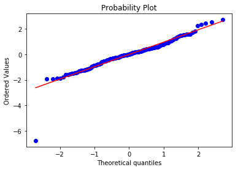

```python
# QQPLOT
probplot(st_adv_residual, dist="norm", plot = pylab)
plt.show()
```

# Shapiro Wilk Test

1. Null Hypothesis - Residuals are Following the Normal Dist Pattern
2. Alternate Hyp - Residuals are Not Following the Gaussian Curve

```python
# Normality Test
from scipy.stats import shapiro, boxcox
shapiro(model_adv.resid) # Data is Not Normal
```

```
(0.9146578311920166, 2.405071697353378e-09)
```

```python
3.938041004403203e-09<0.05
```

```
True
```

```python
from sklearn.preprocessing import StandardScaler
```

```python
ss = StandardScaler()
```

```python
newadv = pd.DataFrame(ss.fit_transform(adv))
```

```python
newadv.columns = adv.columns
```

```python
newadv.head()
```

|  | TV | Radio | Newspaper | Sales |
| --- | --- | --- | --- | --- |
| 0 | 0.969852 | 0.981522 | 1.778945 | 1.552053 |
| 1 | -1.197376 | 1.082808 | 0.669579 | -0.696046 |
| 2 | -1.516155 | 1.528463 | 1.783549 | -0.907406 |
| 3 | 0.052050 | 1.217855 | 1.286405 | 0.860330 |
| 4 | 0.394182 | -0.841614 | 1.281802 | -0.215683 |

```python
x = adv.drop("Sales", axis= 1)
x = sms.add_constant(x)
y = adv.Sales
```

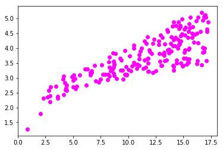

```python
plt.scatter(np.sqrt(adv.TV), np.sqrt(adv.Sales), color="magenta")
```

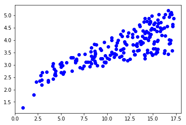

```python
plt.scatter(np.sqrt(adv.TV), np.sqrt(adv.Sales), color="b")
```

```python
# Transforming the Adv Data
adv.TV = np.sqrt(adv.TV)
adv.Radio = np.sqrt(adv.Radio)
adv.Newspaper = np.sqrt(adv.Newspaper)
adv.Sales=np.sqrt(adv.Sales)
```

```python
ss
```

```
StandardScaler(copy=True, with_mean=True, with_std=True)
```